# Time series analysis

Guy Lomax

2022-08-29

This analysis constructs simple time series regression models for the relationship between rangeland GPP and precipitation.

```r
options(repos = c(CRAN = "https://cran.rstudio.org"))
.libPaths("C:/Program Files/Microsoft/R Open/R-4.0.2/library")

library(tidyverse)
library(lubridate)
library(xts)
library(zoo)
```

Load datasets (time series for 100 sampled points in Kenyan rangelands):

```r
data <- read_csv("raw_data/csv/study_area_points_ts.csv") %>%
  mutate(id = paste0("0x", substring(`system:index`, 12)) %>% strtoi(),
         start = as_datetime(start / 1000),
         end = as_datetime(end / 1000)) %>%
  select(id, start, end, GPP, precipitation, LC_Type1) %>%
  rename(LC = LC_Type1) %>%
  arrange(start) %>%
  arrange(id)
head(data)
```

| id | start | end | GPP | precipitation | LC |
| --- | --- | --- | --- | --- | --- |
| 0 | 2002-01-01 | 2002-01-09 | 437 | 0.000000 | 10 |
| 0 | 2002-01-09 | 2002-01-17 | 426 | 0.000000 | 10 |
| 0 | 2002-01-17 | 2002-01-25 | 319 | 4.393273 | 10 |
| 0 | 2002-01-25 | 2002-02-02 | 316 | 0.000000 | 10 |
| 0 | 2002-02-02 | 2002-02-10 | 279 | 0.000000 | 10 |
| 0 | 2002-02-10 | 2002-02-18 | 253 | 0.000000 | 10 |

[output not shown]

```r
# Assign mid-point of time window as date
# Add period-of-year variable


data_mid <- data %>%
  mutate(midpoint = start + as.duration(interval(start, end) / 2),
         year = year(midpoint),
         week_num = (yday(end) - 1) / 8)
```

Exploration of data

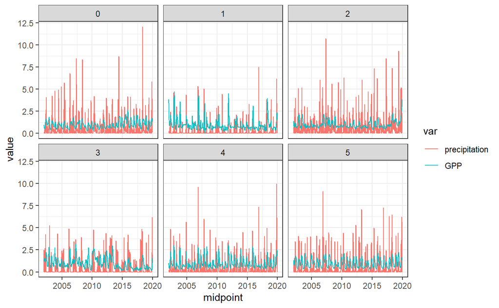

```r
# Normalise ppt and GPP to mean values and plot

test_plot <- data_mid %>%
  group_by(id) %>%
  mutate(precipitation = precipitation / mean(precipitation[precipitation != 0]),
         GPP = GPP / mean(GPP)) %>%
  ungroup() %>%
  filter(id < 6) %>%
  pivot_longer(cols = c(GPP, precipitation),
               names_to = "var",
               values_to = "value") %>%
  mutate(var = factor(var, levels = c("precipitation", "GPP"))) %>%
  ggplot() +
  geom_line(aes(x = midpoint, y = value, colour = var)) +
  facet_wrap(~id, nrow = 2, ncol = 3) +
  theme_bw()

test_plot
```

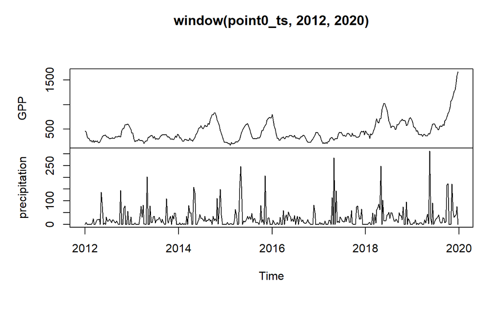

```r
point0 <- filter(data_mid, id == 2)

point0_ts <- point0 %>%
  select(GPP, precipitation) %>%
  ts(frequency = 46, start = c(2002, 1))

gpp_ts <- ts(point0$GPP, frequency = 46, start = c(2002, 1))

precip_ts <- ts(point0$precipitation, frequency = 46, start = c(2002, 1))

plot(window(point0_ts, 2012, 2020))
```

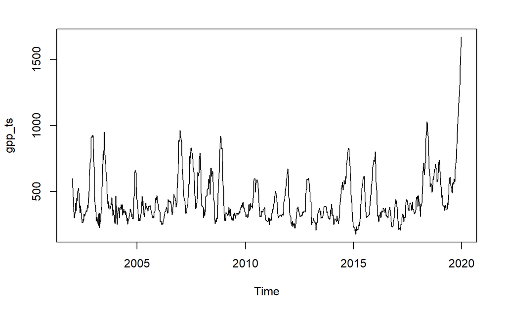

```r
plot(gpp_ts)
```

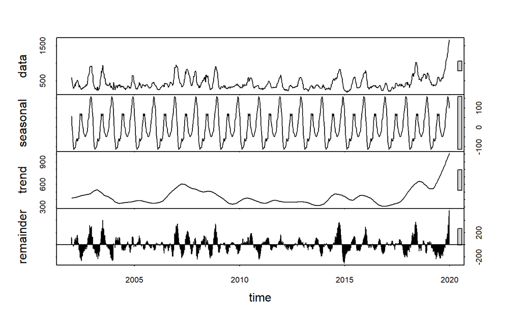

```r
plot(stl(gpp_ts, s.window = "periodic"))
```

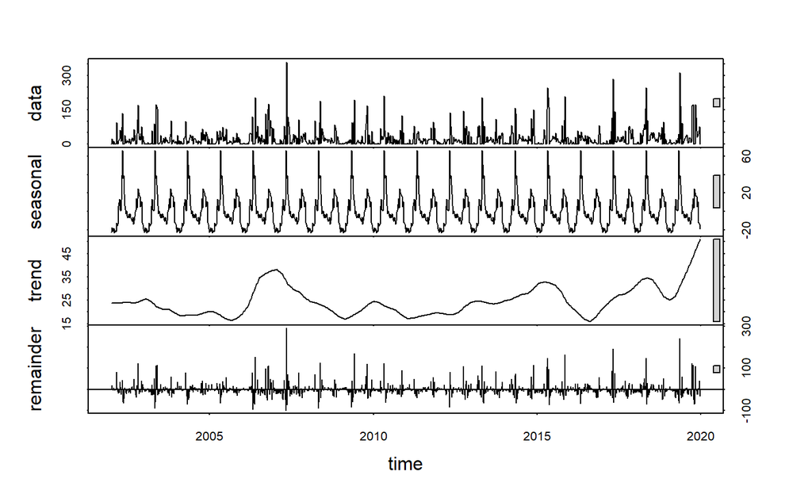

```r
plot(stl(precip_ts, s.window = "periodic"))
```

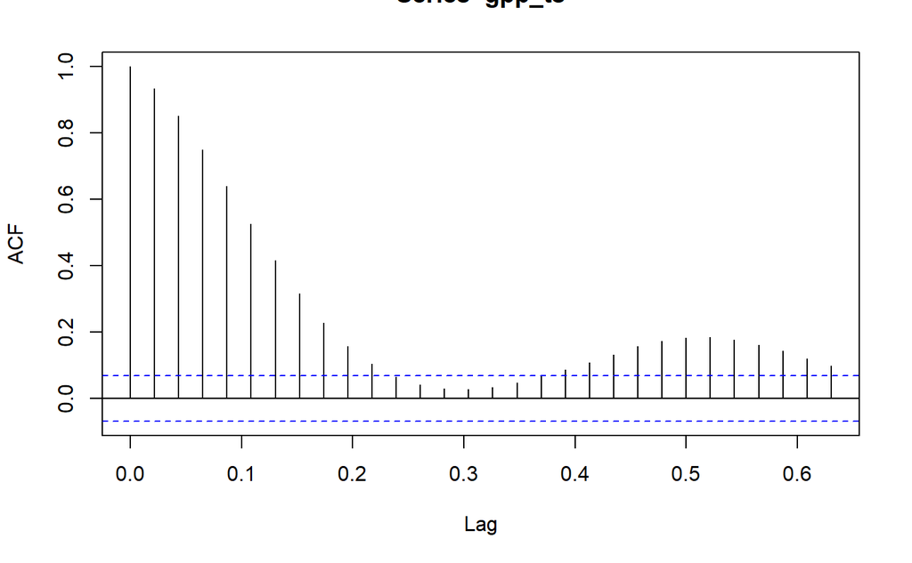

```r
# Autocorrelation in datasets
acf(gpp_ts)
```

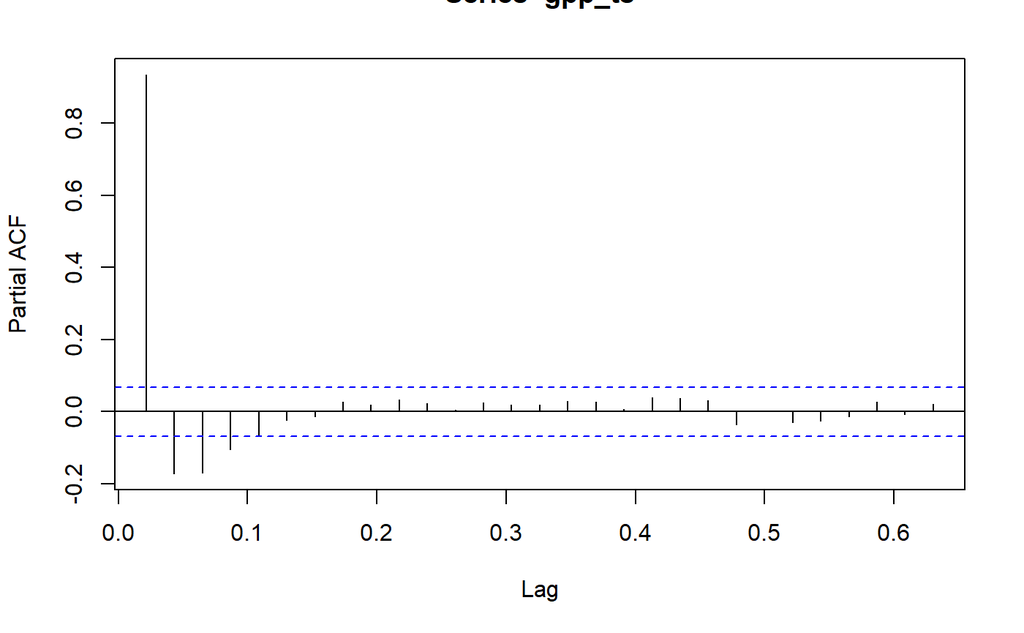

```r
pacf(gpp_ts)
```

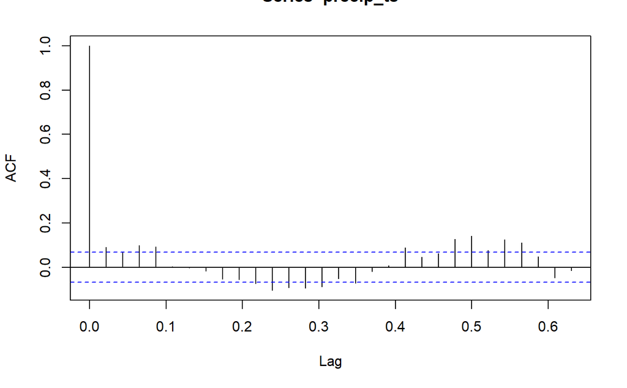

```r
acf(precip_ts)
```

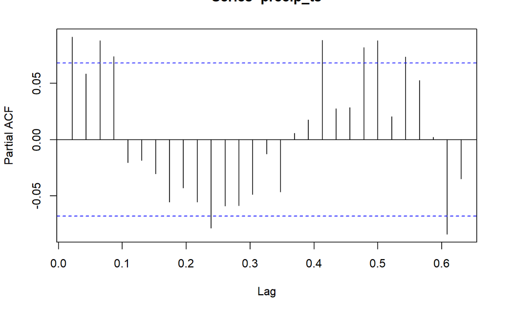

```r
pacf(precip_ts)
```

```r
NA
NA
```

GPP appears to have a stronger autocorrelation and slower variation than PPT, reflecting the fact it is a slower-responding variable. Visually, GPP seems to respond more to the cumulative amount of rainfall than the magnitude of any spike, and to be more sensitive to rainfall after periods of low rainfall than after periods of high rainfall (intuitive!). For example, in late 2006, a small amount of rainfall is correlated with a significant increase in GPP, while simi lar rainfall in mid-2006 occurs at a time of higher, but declining, GPP. This suggests a few things: 1. Cumulative rainfall over some characteristic timescale may be more relevant than individual rainfall. 2. The GPP-precipitation relationship is nonlinear, but depends on (i) the amount of rainfall and (ii) the state of the vegetation/GPP when that rainfall occurs. 3. The response to rainfall varies depending on the timing in the season. Rainfall occurring after a dry period leads to a strong response, while rainfall occurring late in the season when GPP is already declining shows a weaker response. 4. There isn’t an obvious pattern where GPP increase at the start of a season is faster than GPP decrease at the end, or vice versa. Instead, there seem to be some years when GPP increases slowly and declines rapidly (2007) and some where it increases rapidly and declines slowly (2008). Could this be a lag effect?

Point 2 also seems to have an unusual relationship, with large GPP responses to small rainfall totals in some years (e.g., 2008) and small responses to large events in others (e.g., 2009). Could this be a memory effect from previous years?

Here’s a simple first attempt to fit a linear model including an autoregressive component.

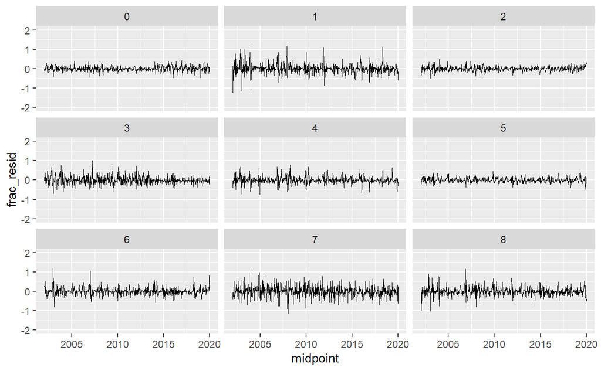

```r
data_nest <- data_mid %>%
  group_by(id) %>%
  nest()

# Fit linear models to each data point
# Define linear model function (easy to edit formula)
lin_mod <- function(df) {
  mod <- lm(GPP ~ lag(GPP) + precipitation + lag(precipitation),
            data = df)
  mod
}

# Map function across nested data frames for each data point
data_lm <- data_nest %>%
  summarise(mod = map(data, lin_mod),
            preds = map2(data, mod, add_predictions),
            resids = map2(data, mod, add_residuals))

lm_resids <- unnest(data_lm, resids)

lm_resids %>%
  filter(id < 9) %>%
  group_by(id) %>%
  mutate(frac_resid = resid / mean(GPP)) %>%
  ungroup() %>%
  ggplot(aes(x = midpoint, y = frac_resid)) +
  geom_line(size = 0.2) +
  facet_wrap(~id) +
  ylim(-2, 2)
```

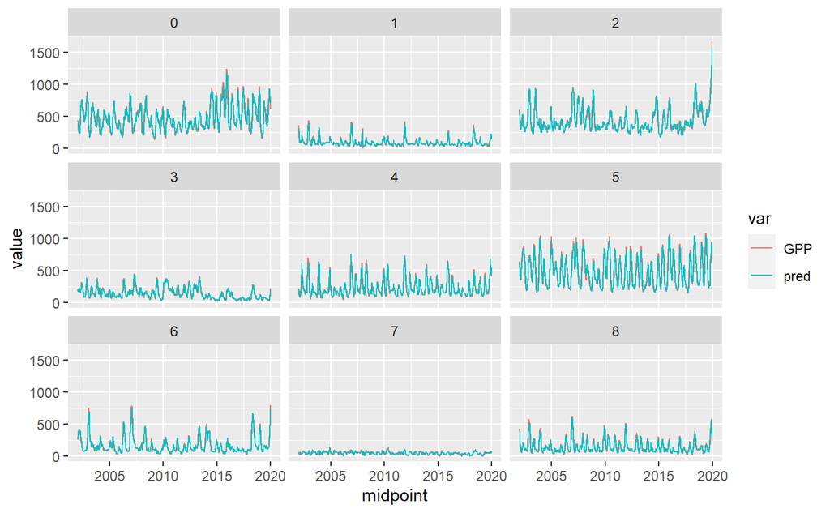

```r
lm_preds <- unnest(data_lm, preds)

lm_preds %>%
  filter(id < 9) %>%
  select(id, midpoint, GPP, precipitation, pred) %>%
  pivot_longer(c(GPP, pred), names_to = "var", values_to = "value") %>%
  ggplot(aes(x = midpoint, y = value, colour = var)) +
  geom_line(size = 0.4) +
  facet_wrap(~id)
```

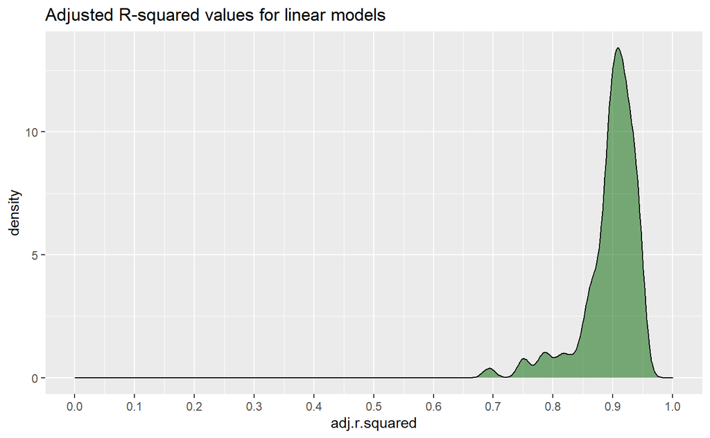

```r
# Model performance

lm_performance <- data_lm %>%
  mutate(glance = map(mod, broom::glance)) %>%
  select(-preds, -resids) %>%
  unnest(glance)

# Density plots of model performance metrics
lm_performance %>%
  ggplot(aes(x = adj.r.squared)) +
  geom_density(fill = "darkgreen", alpha = 0.5) +
  scale_x_continuous(breaks = seq(0, 1, 0.1), limits = c(0,1)) +
  labs(title = "Adjusted R-squared values for linear models")
```

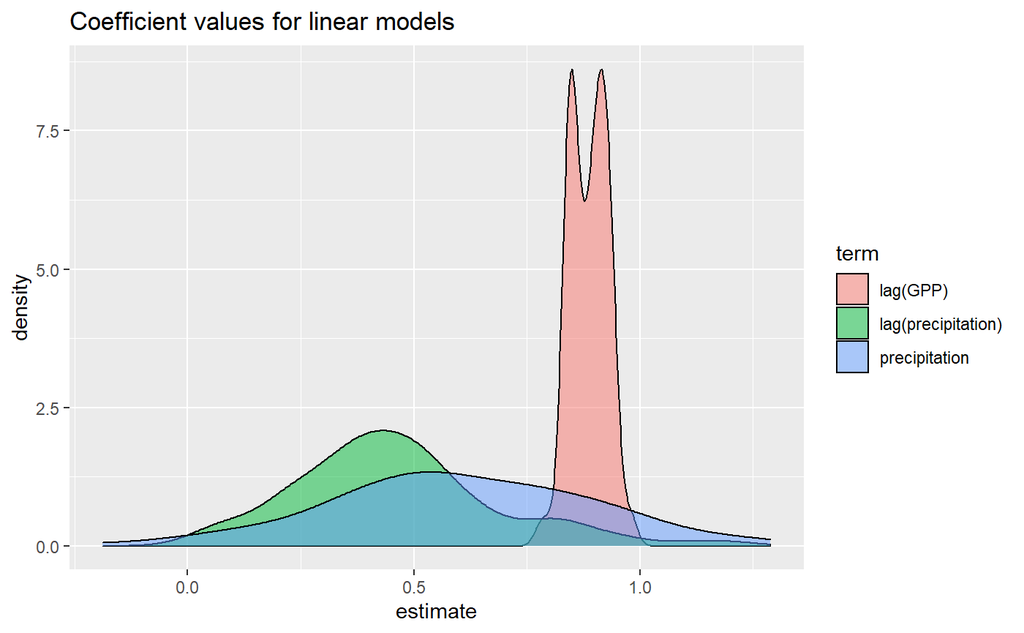

```r
# Extract coefficient values
lm_coefficients <- data_lm %>%
  select(id, mod) %>%
  mutate(coef = map(mod, broom::tidy)) %>%
  unnest(coef)

# Plot density plot of coefficient values

lm_coefficients %>%
  filter(term != "(Intercept)") %>%
  ggplot(aes(x = estimate, fill = term)) +
  geom_density(position = "identity", alpha = 0.5) +
  labs(title = "Coefficient values for linear models")
```

At first glance, the simple linear models appear to predict actual GPP extremely closely. However, much of this reflects the strong autocorrelation on the short time steps considered in this dataset. I should try fitting a GAMM.

[figure not shown]